# Homework1-XAI2022-Pawel-Fijalkowski

Paweł Fijałkowski

2022-03-30

## Initial:

As the package was removed from CRAN, we needed to download it directly from GitHub (using Rstudio Cloud, as it only worked *somehow*).

```r
EPL_2021 <- read.csv("EPL_2021.csv")
head(EPL_2021)
```

|  | league | id | minute | result | X | Y | xG | player | h_a | player_id | situation | season | shotType | match_id | home_team | away_team | home_goals | away_goals | date | player_assisted | lastAction |
| --- | --- | --- | --- | --- | --- | --- | --- | --- | --- | --- | --- | --- | --- | --- | --- | --- | --- | --- | --- | --- | --- |
| 1 | EPL | 425564 | 10 | MissedShots | 0.913 | 0.539 | 0.05346401 | Frank Onyeka | h | 9681 | OpenPlay | 2021 | Head | 16376 | Brentford | Arsenal | 2 | 0 | 2021-08-13 19:00:00 | NA | Aerial |
| 2 | EPL | 425565 | 11 | ShotOnPost | 0.908 | 0.315 | 0.11829661 | Bryan Mbeumo | h | 6552 | OpenPlay | 2021 | RightFoot | 16376 | Brentford | Arsenal | 2 | 0 | 2021-08-13 19:00:00 | Ivan Toney | Throughball |
| 3 | EPL | 425567 | 21 | Goal | 0.874 | 0.698 | 0.05214472 | Sergi Canos | h | 1078 | OpenPlay | 2021 | RightFoot | 16376 | Brentford | Arsenal | 2 | 0 | 2021-08-13 19:00:00 | Ethan Pinnock | BallRecovery |
| 4 | EPL | 425568 | 27 | MissedShots | 0.812 | 0.478 | 0.06570620 | Sergi Canos | h | 1078 | OpenPlay | 2021 | RightFoot | 16376 | Brentford | Arsenal | 2 | 0 | 2021-08-13 19:00:00 | Frank Onyeka | Pass |
| 5 | EPL | 425569 | 29 | MissedShots | 0.892 | 0.357 | 0.08069062 | Bryan Mbeumo | h | 6552 | OpenPlay | 2021 | RightFoot | 16376 | Brentford | Arsenal | 2 | 0 | 2021-08-13 19:00:00 | Kristoffer Ajer | Chipped |
| 6 | EPL | 425579 | 65 | SavedShot | 0.882 | 0.332 | 0.07258376 | Sergi Canos | h | 1078 | OpenPlay | 2021 | RightFoot | 16376 | Brentford | Arsenal | 2 | 0 | 2021-08-13 19:00:00 | Bryan Mbeumo | Pass |

Each row in the data set is a shot attempt. Provided features (“league”, “shotType”, “home_team”, “away_team”, …) are supposed to help us in predicting “xG” value which essentially is a probability that this attempt will end up with a positive result (a goal).

Here we select features that are important in the context of our problem and do proper transformations ((X,Y) -> (distance, angle))

```r
library(dplyr)
data <- EPL_2021 %>% select(result, X, Y, xG, h_a, situation, shotType, home_goals, away_goals, lastAction) %>%
                 mutate(status = ifelse(result == "Goal", "1", "0")) %>%
                 mutate(distanceToGoal = sqrt((105 - (X * 105)) ^ 2 + (32.5 - (Y * 68)) ^ 2)) %>%
                 mutate(angleToGoal = abs(atan((7.32 * (105 - (X * 105))) / ((105 - (X * 105))^2 +
                (32.5 - (Y * 68)) ^ 2 - (7.32 / 2) ^ 2)) * 180 / pi)) %>%
                 select(-X, -Y, -result)
```

## Models:

We will be predicting probability of scoring a goal (status) for each shot attempt.

```r
library(DALEX)
library(DALEXtra)
library(ranger)
```

```r
data_processed <- data  %>% mutate(h_a = as.factor(h_a),
                                        situation = as.factor(situation),
                                        shotType = as.factor(shotType),
                                        lastAction = as.factor(lastAction),
                                        status = as.numeric(status))

model <- ranger::ranger(status ~., data = data_processed, classification = TRUE, probability = TRUE)
```

## Explanations

#### Making prediction:

```r
obs40 <- data_processed[40, !(colnames(data_processed) %in% c("status"))]
predict_40 <- predict(model, obs40)
ifelse(predict_40$predictions[2] <= 0.5, 0, 1)
```

```
## [1] 0
```

```r
data_processed[12, "status"]
```

```
## [1] 0
```

Let’s create explainer!

```r
explainer <- explain(model, data = data_processed, y = as.numeric(data_processed$status))
```

```
## Preparation of a new explainer is initiated
##   -> model label       :  ranger  (  default  )
##   -> data              :  7389  rows  10  cols
##   -> target variable   :  7389  values
##   -> predict function  :  yhat.ranger  will be used (  default  )
##   -> predicted values  :  No value for predict function target column. (  default  )
##   -> model_info        :  package ranger , ver. 0.13.1 , task classification (  default  )
##   -> predicted values  :  numerical, min =  0 , mean =  0.1066805 , max =  0.9838016
##   -> residual function :  difference between y and yhat (  default  )
##   -> residuals         :  numerical, min =  -0.7995832 , mean =  -0.002200902 , max =  0.6997594
##   A new explainer has been created!
```

Break Down for observation #40

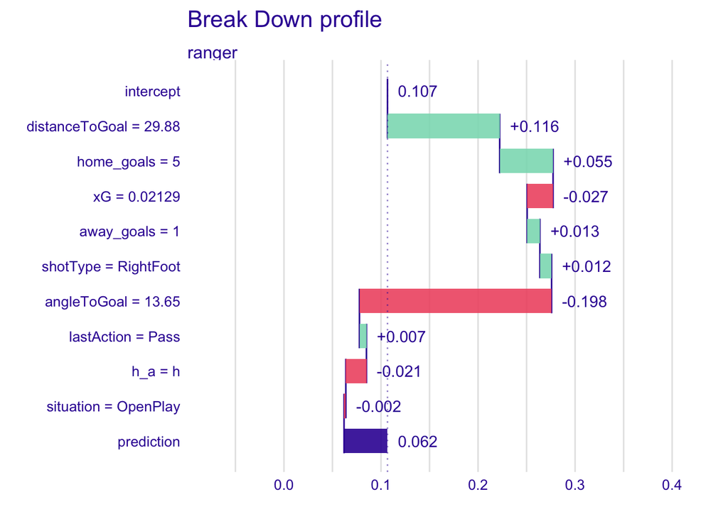

```r
plot(predict_parts(explainer = explainer, new_observation = obs40))
```

The angle to the goal contributes heavily negatively to the result (scoring goal).

Shap on observation 40

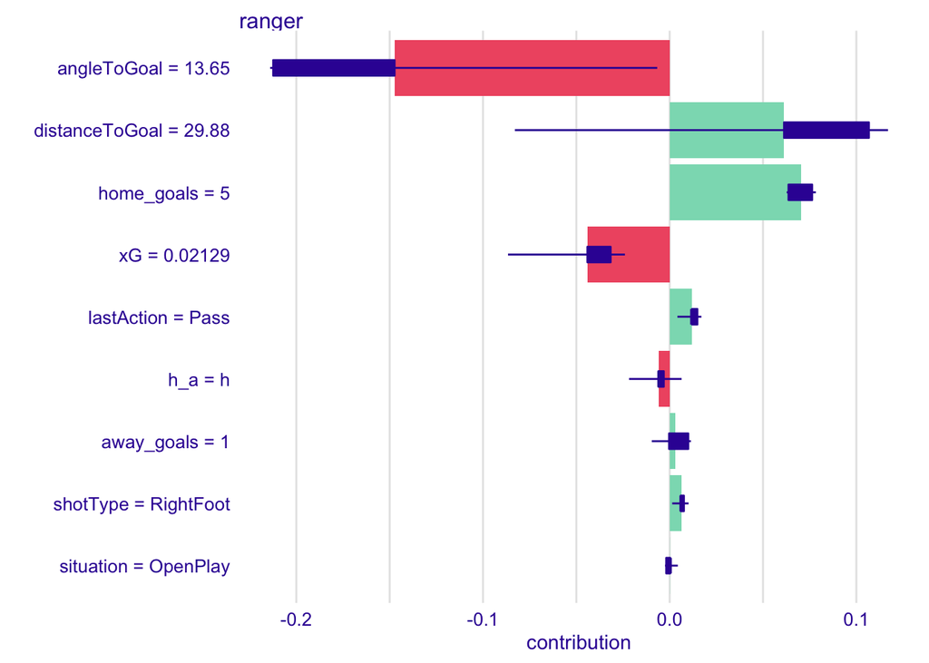

```r
plot(predict_parts(explainer = explainer, new_observation = obs40, type = 'shap', B = 4))
```

We clearly see that low quality of the attempt (xG) and angleToGoal contributed negatively.

We will find 2 observations in which the same feature have different effect.

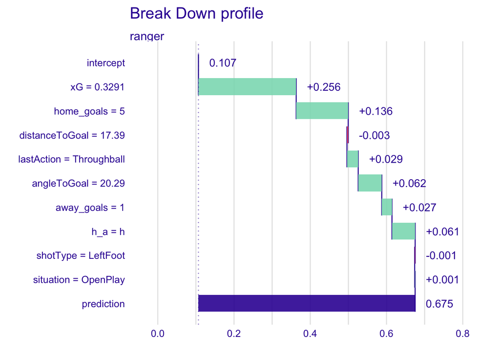

```r
obs37 <- data_processed[37, !(colnames(data_processed) %in% c("status"))]
plot(predict_parts(explainer = explainer, new_observation = obs37))
```

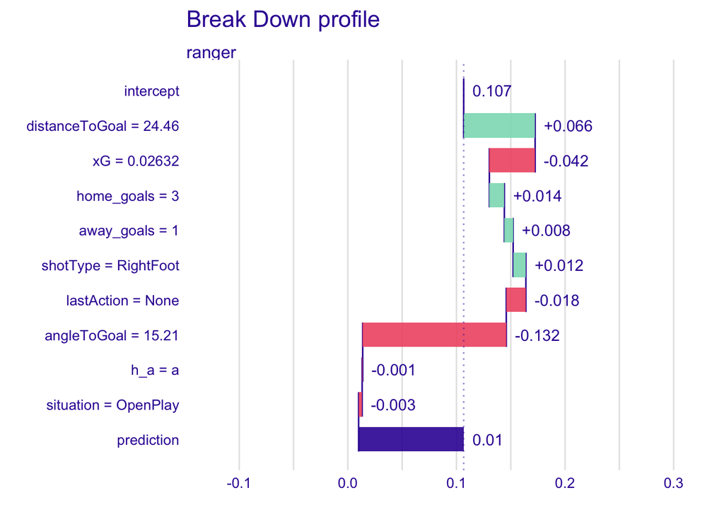

```r
obs120 <- data_processed[120, !(colnames(data_processed) %in% c("status"))]
plot(predict_parts(explainer = explainer, new_observation = obs120))
```

As we can see “xG” value can contribute negatively(120) or positively(37) to the status variable.